| title: ‘Practical Machine Learning Project’ |
| --- |
| author: “Philip Short” |
| output: |
| html_document: |
| keep_md: yes |
| toc: yes |

```
## Run time: 2016-06-07 16:05:49
## R version: R version 3.2.3 (2015-12-10)
```

> **Background**

> Using devices such as Jawbone Up, Nike FuelBand, and Fitbit it is now possible to collect a large amount of data about personal activity relatively inexpensively. These type of devices are part of the quantified self movement - a group of enthusiasts who take measurements about themselves regularly to improve their health, to find patterns in their behavior, or because they are tech geeks. One thing that people regularly do is quantify how much of a particular activity they do, but they rarely quantify how well they do it. In this project, your goal will be to use data from accelerometers on the belt, forearm, arm, and dumbell of 6 participants. They were asked to perform barbell lifts correctly and incorrectly in 5 different ways. More information is available from the website here: http://groupware.les.inf.puc-rio.br/har (see the section on the Weight Lifting Exercise Dataset).

### Summary

The data set was reviewed after cleaning up the data and fitting a model. The goal was to be able to have an accurate model to predict the class of the perfomed exersise. The class is the value giving to a correct bicep curl (A) and incorrect form (B-E). The RandomForest Prediction model was selected to predict the class (A-E) after comparison to the Gradient Boosting model. Using the RandomForest model, a Kappa value of 0.995 and an accuracy of 0.996 was acchived. The model was then used to determine the class of 20 bicep curls. The model was able to correctly predict the class of the exercise.

### Prepare and cleaning the datasets

Load the needed libraries for analysis.

```r
library(data.table)
library(caret)
library(lattice)
```

Load the testing data into a data table.

```r
url1 <- "http://d396qusza40orc.cloudfront.net/predmachlearn/pml-training.csv"
download.file(url1, destfile="pml-training.csv")
url2 <- "http://d396qusza40orc.cloudfront.net/predmachlearn/pml-testing.csv"
download.file(url2, destfile="pml-testing.csv")
dataTrain <- read.csv("pml-training.csv", header=TRUE)
dataTest <- read.csv("pml-testing.csv", header=TRUE)
```

Lets look at the data that is going to be used from the pml-training.csv set.

```r
dim(dataTrain)
```

```
## [1] 19622   160
```

As it can be seen from the sample of data, some variables need to be removed from the model due to the high level of NAs and blanks that are contained. For example, the summary below for var_total_accel belt shows that this variable should be removed for the model.

```r
summary(dataTrain$var_total_accel_belt)
```

```
##    Min. 1st Qu.  Median    Mean 3rd Qu.    Max.    NA's
##   0.000   0.100   0.200   0.926   0.300  16.500   19216
```

```r
removeNa <- is.na(dataTrain)
removeColumns <- which(colSums(removeNa)>18000)
dataTrain <- dataTrain[,-removeColumns]
```

Next, after excluding such values metioned above the data is cleaned up to remove unwanted coloumns.

```r
dataTidy <- dataTrain[,-c(grep("^amplitude|^kurtosis|^skewness|^avg|^cvtd_timestamp|^max|^min|^new_window|^raw_timestamp|^stddev|^var|^user_name|X",names(dataTrain)))]

paste("Complete Cases:")
```

```
## [1] "Complete Cases:"
```

```r
table(complete.cases(dataTidy))
```

```
##
##  TRUE
## 19622
```

```r
dataTidy[1,]
```

```
##   num_window roll_belt pitch_belt yaw_belt total_accel_belt gyros_belt_x
## 1         11      1.41       8.07    -94.4                3            0
##   gyros_belt_y gyros_belt_z accel_belt_x accel_belt_y accel_belt_z
## 1            0        -0.02          -21            4           22
##   magnet_belt_x magnet_belt_y magnet_belt_z roll_arm pitch_arm yaw_arm
## 1            -3           599          -313     -128      22.5    -161
##   total_accel_arm gyros_arm_x gyros_arm_y gyros_arm_z accel_arm_x
## 1              34           0           0       -0.02        -288
##   accel_arm_y accel_arm_z magnet_arm_x magnet_arm_y magnet_arm_z
## 1         109        -123         -368          337          516
##   roll_dumbbell pitch_dumbbell yaw_dumbbell total_accel_dumbbell
## 1      13.05217        -70.494    -84.87394                   37
##   gyros_dumbbell_x gyros_dumbbell_y gyros_dumbbell_z accel_dumbbell_x
## 1                0            -0.02                0             -234
##   accel_dumbbell_y accel_dumbbell_z magnet_dumbbell_x magnet_dumbbell_y
## 1               47             -271              -559               293
##   magnet_dumbbell_z roll_forearm pitch_forearm yaw_forearm
## 1               -65         28.4         -63.9        -153
##   total_accel_forearm gyros_forearm_x gyros_forearm_y gyros_forearm_z
## 1                  36            0.03               0           -0.02
##   accel_forearm_x accel_forearm_y accel_forearm_z magnet_forearm_x
## 1             192             203            -215              -17
##   magnet_forearm_y magnet_forearm_z classe
## 1              654              476      A
```

As seen from one row from dataTidy, the Class variable is still present along with acceleromter data. This is the data we will use to build a predictive model.

### Data Splitting

The tidy data will be split into a 60% training set and a 40% testing set. The seed is set to 50.

```r
set.seed(50)
inTrain <- createDataPartition(y=dataTidy$classe,p=0.6,list=FALSE)
dataTidyTrain <- dataTidy[inTrain,]
dataTidyTest <- dataTidy[-inTrain,]
```

### Model Comparison and Selection

The goal of the comparison is to discover which algorithm suits the data better. The RandomForest (rf) and Gradient Boosting (gbm) algorithms are selected for comparison based on the accuracy these algorithms can achieve in classification. These 2 models have built-in feature selection as described in the Caret package reference. The Kappa metric is selected as the comparison criteria between the two models. To reduce the risk of overfitting, a 10-fold cross validation is used model building

```r
fitControl <- trainControl(method = "cv", number = 10)
gbmFit <- train(classe~., data=dataTidyTrain, method="gbm", metric="Kappa", trControl=fitControl,verbose=FALSE)
rfFit <- train(classe~.,data=dataTidyTrain,method="rf", metric="Kappa", trControl=fitControl)
```

The models are then compared using the resamples function from the Caret package.

```r
rValues <- resamples(list(rf=rfFit,gbm=gbmFit))
summary(rValues)
```

```
##
## Call:
## summary.resamples(object = rValues)
##
## Models: rf, gbm
## Number of resamples: 10
##
## Accuracy
##       Min. 1st Qu. Median   Mean 3rd Qu.   Max. NA's
## rf  0.9915  0.9966 0.9966 0.9969  0.9987 1.0000    0
## gbm 0.9813  0.9824 0.9864 0.9856  0.9881 0.9898    0
##
## Kappa
##       Min. 1st Qu. Median   Mean 3rd Qu.   Max. NA's
## rf  0.9893  0.9957 0.9957 0.9960  0.9984 1.0000    0
## gbm 0.9764  0.9777 0.9828 0.9817  0.9850 0.9871    0
```

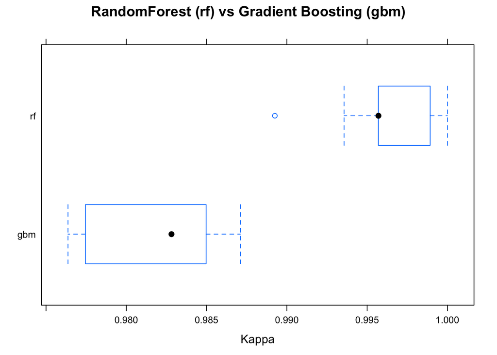

```r
bwplot(rValues,metric="Kappa",main="RandomForest (rf) vs Gradient Boosting (gbm)")
```

### Model Validation

The details of the RandomForest model are seen below.

```r
rfFit
```

```
## Random Forest
##
## 11776 samples
##    53 predictor
##     5 classes: 'A', 'B', 'C', 'D', 'E'
##
## No pre-processing
## Resampling: Cross-Validated (10 fold)
## Summary of sample sizes: 10598, 10598, 10599, 10597, 10598, 10598, ...
## Resampling results across tuning parameters:
##
##   mtry  Accuracy   Kappa
##    2    0.9929518  0.9910840
##   27    0.9968576  0.9960253
##   53    0.9923574  0.9903339
##
## Kappa was used to select the optimal model using  the largest value.
## The final value used for the model was mtry = 27.
```

Using the confusion matrix found inthe Caret package, the model iwth the test data set will be tested using the confusionMatrix function.

```r
confusionMatrix(dataTidyTest$classe, predict(rfFit,dataTidyTest))
```

```
## Confusion Matrix and Statistics
##
##           Reference
## Prediction    A    B    C    D    E
##          A 2231    1    0    0    0
##          B   10 1507    1    0    0
##          C    0    3 1365    0    0
##          D    0    0    6 1280    0
##          E    0    0    0    5 1437
##
## Overall Statistics
##
##                Accuracy : 0.9967
##                  95% CI : (0.9951, 0.9978)
##     No Information Rate : 0.2856
##     P-Value [Acc > NIR] : < 2.2e-16
##
##                   Kappa : 0.9958
##  Mcnemar's Test P-Value : NA
##
## Statistics by Class:
##
##                      Class: A Class: B Class: C Class: D Class: E
## Sensitivity            0.9955   0.9974   0.9949   0.9961   1.0000
## Specificity            0.9998   0.9983   0.9995   0.9991   0.9992
## Pos Pred Value         0.9996   0.9928   0.9978   0.9953   0.9965
## Neg Pred Value         0.9982   0.9994   0.9989   0.9992   1.0000
## Prevalence             0.2856   0.1926   0.1749   0.1638   0.1832
## Detection Rate         0.2843   0.1921   0.1740   0.1631   0.1832
## Detection Prevalence   0.2845   0.1935   0.1744   0.1639   0.1838
## Balanced Accuracy      0.9977   0.9978   0.9972   0.9976   0.9996
```

The model generated performs at a Kappa value of 0.995 and an accuracy of 0.996 to the test data set.

### Final Testing

```r
results <- predict(rfFit,newdata=dataTest)
print(as.data.frame(results))
```

```
##    results
## 1        B
## 2        A
## 3        B
## 4        A
## 5        A
## 6        E
## 7        D
## 8        B
## 9        A
## 10       A
## 11       B
## 12       C
## 13       B
## 14       A
## 15       E
## 16       E
## 17       A
## 18       B
## 19       B
## 20       B
```